##### 05/03/2023

# INFO 4120 Midterm Project

## EXECUTIVE SUMMARY

Income inequality has risen in most countries since the 1990s and continues to worsen. Education is widely acknowledged as a significant contributor to income inequality. This project aims to investigate the relationship between education expansion and income inequality and explore whether higher income and education lead to consistent happiness.

As income inequality has significant economic and social consequences, understanding the relationship between income inequality, education expansion, and happiness is essential for policymakers to develop effective strategies to address these issues. Income inequality can have significant economic and social consequences, such as reduced economic growth and political instability. Furthermore, access to education is critical for individuals to improve their socio-economic status and quality of life. However, disparities in educational opportunities and outcomes can further exacerbate income inequality, as those who lack access to quality education may struggle to compete in the job market and earn a decent income. Finally, while the correlation between income, education, and happiness is complex, it is vital to explore this relationship as it can have implications for individual well-being and societal welfare. By gaining a better understanding of these factors, we can work towards creating a more equitable and fulfilling society.

To explore the relationships between income inequality, education, and happiness, this project will analyze three distinct datasets, each offering valuable insights into these key topics.

## RESEARCH QUESTIONS

Based on the objectives and context of the project, the potential research questions that will be explored are:

1. What is the relationship between income and education level? What is the relationship between income inequality and education expansion across the different areas?
2. How does income impact individual happiness?
3. How does education impact individual happiness?
4. What is the relationship between education level, income, and happiness?

## DATA

```python
# Importing Packages
import pandas as pd  # For dataframe manipulation
import numpy as np # For matrix and numerical calculations; foundation of pandas
from pandas import Series, DataFrame
from numpy import nan as NA
import matplotlib.pyplot as plt# For visualizations and plotting
%matplotlib inline
import seaborn as sns # For visualizations and plotting
import plotly.express as px
```

### Getting the data

The datasets used in this research were obtained from the following data sources:

1. Kaggle  
   World Happiness Report: https://www.kaggle.com/datasets/unsdsn/world-happiness?select=2019.csv
2. Our World in Data  
   World Bank Income Groups: https://ourworldindata.org/grapher/world-banks-income-groups  
   Global Education: https://ourworldindata.org/global-education

### Storing the data

#### Education Dataset

```python
#Loading the first Dataset into the DataFrame df1
df1 = pd.read_csv('Education.csv')

#Getting the first 4 rows
df1.head(4)
```

|  | Entity | Code | Year | Barro-Lee: Percentage of population age 15+ with tertiary schooling. Completed Tertiary |
| --- | --- | --- | --- | --- |
| 0 | Afghanistan | AFG | 1970 | 1.08 |
| 1 | Afghanistan | AFG | 1975 | 1.48 |
| 2 | Afghanistan | AFG | 1980 | 1.96 |
| 3 | Afghanistan | AFG | 1985 | 2.49 |

```python
#Renaming some columns
df1 = df1.rename(columns={'Entity': 'Country','Barro-Lee: Percentage of population age 15+ with tertiary schooling. Completed Tertiary':'% with tertiary schooling'})
```

```python
#Keeping just data for 2010, because it is the most recent data
df1= df1[df1['Year'] == 2010]
print(df1)
```

```
          Country Code  Year  % with tertiary schooling
8     Afghanistan  AFG  2010                       3.65
17        Albania  ALB  2010                       0.93
26        Algeria  DZA  2010                       6.66
35      Argentina  ARG  2010                       2.87
44        Armenia  ARM  2010                      15.03
...           ...  ...   ...                        ...
1259    Venezuela  VEN  2010                       2.96
1268      Vietnam  VNM  2010                       3.27
1277        Yemen  YEM  2010                       1.50
1286       Zambia  ZMB  2010                       0.49
1295     Zimbabwe  ZWE  2010                       0.38

[144 rows x 4 columns]
```

```python
#Droping the 'Year' Column because it is now the same for all the countries, and the 'Code' column because we are not going to use it
df1 = df1.drop(['Year', 'Code'], axis=1)
```

```python
#Checking the output
df1.head(4)
```

|  | Country | % with tertiary schooling |
| --- | --- | --- |
| 8 | Afghanistan | 3.65 |
| 17 | Albania | 0.93 |
| 26 | Algeria | 6.66 |
| 35 | Argentina | 2.87 |

```python
#Printing df1 information
df1.info()
```

```
<class 'pandas.core.frame.DataFrame'>
Int64Index: 144 entries, 8 to 1295
Data columns (total 2 columns):
 #   Column                     Non-Null Count  Dtype
---  ------                     --------------  -----
 0   Country                    144 non-null    object
 1   % with tertiary schooling  144 non-null    float64
dtypes: float64(1), object(1)
memory usage: 3.4+ KB
```

#### Happiness Dataset

```python
#Loading the second Dataset into the DataFrame df2
df2 = pd.read_csv('happiness.csv')

#Getting the first 4 rows
df2.head(4)
```

|  | Overall rank | Country or region | Score | GDP per capita | Social support | Healthy life expectancy | Freedom to make life choices | Generosity | Perceptions of corruption |
| --- | --- | --- | --- | --- | --- | --- | --- | --- | --- |
| 0 | 154 | Afghanistan | 3.203 | 0.350 | 0.517 | 0.361 | 0.000 | 0.158 | 0.025 |
| 1 | 107 | Albania | 4.719 | 0.947 | 0.848 | 0.874 | 0.383 | 0.178 | 0.027 |
| 2 | 88 | Algeria | 5.211 | 1.002 | 1.160 | 0.785 | 0.086 | 0.073 | 0.114 |
| 3 | 47 | Argentina | 6.086 | 1.092 | 1.432 | 0.881 | 0.471 | 0.066 | 0.050 |

```python
#Droping the 'Overall Rank' column because I am not going to use it
df2 = df2.drop(['Overall rank'], axis=1)
```

```python
#Renaming some columns
df2 = df2.rename(columns={'Country or region': 'Country','Score':'Happiness Score'})

#Printing df2 information
df2.info()
```

```
<class 'pandas.core.frame.DataFrame'>
RangeIndex: 156 entries, 0 to 155
Data columns (total 8 columns):
 #   Column                        Non-Null Count  Dtype
---  ------                        --------------  -----
 0   Country                       156 non-null    object
 1   Happiness Score               156 non-null    float64
 2   GDP per capita                156 non-null    float64
 3   Social support                156 non-null    float64
 4   Healthy life expectancy       156 non-null    float64
 5   Freedom to make life choices  156 non-null    float64
 6   Generosity                    156 non-null    float64
 7   Perceptions of corruption     156 non-null    float64
dtypes: float64(7), object(1)
memory usage: 9.9+ KB
```

#### Income Dataset

```python
#Loading the third Dataset into the DataFrame df3
df3 = pd.read_csv('income.csv')

#Getting the first 4 rows
df3.head(4)
```

|  | Country | Income group | Region | Lending category | 1987 | 1988 | 1989 | 1990 | 1991 | 1992 | ... | 2011 | 2012 | 2013 | 2014 | 2015 | 2016 | 2017 | 2018 | 2019 | 2020 |
| --- | --- | --- | --- | --- | --- | --- | --- | --- | --- | --- | --- | --- | --- | --- | --- | --- | --- | --- | --- | --- | --- |
| 0 | Aruba | High income | Latin America & Caribbean | NaN | NaN | 10360.0 | 11760.0 | 12230.0 | 13190.0 | 13990.0 | ... | 22450.0 | 23520.0 | 24510.0 | 25350.0 | 26560.0 | 26840.0 | 27120.0 | NaN | NaN | NaN |
| 1 | Afghanistan | Low income | South Asia | IDA | NaN | NaN | NaN | NaN | NaN | NaN | ... | 530.0 | 630.0 | 660.0 | 630.0 | 600.0 | 550.0 | 530.0 | 520.0 | 530.0 | 500.0 |
| 2 | Angola | Lower middle income | Sub-Saharan Africa | IBRD | 670.0 | 650.0 | 860.0 | 780.0 | 1380.0 | 1170.0 | ... | 3410.0 | 4170.0 | 4780.0 | 5010.0 | 4520.0 | 3770.0 | 3450.0 | 3210.0 | 2970.0 | 2230.0 |
| 3 | Albania | Upper middle income | Europe & Central Asia | IBRD | 730.0 | 730.0 | 760.0 | 650.0 | 410.0 | 280.0 | ... | 4410.0 | 4360.0 | 4540.0 | 4540.0 | 4390.0 | 4320.0 | 4290.0 | 4860.0 | 5220.0 | 5210.0 |

4 rows × 38 columns

```python
#Deleting columns from 'Lending category' to '2020' because I am not going to use them
df3.drop(df3.loc[:,'Lending category':'2020'], axis=1, inplace = True)

#Checking the output
df3.head(4)
```

|  | Country | Income group | Region |
| --- | --- | --- | --- |
| 0 | Aruba | High income | Latin America & Caribbean |
| 1 | Afghanistan | Low income | South Asia |
| 2 | Angola | Lower middle income | Sub-Saharan Africa |
| 3 | Albania | Upper middle income | Europe & Central Asia |

```python
#Printing df3 information
df3.info()
```

```
<class 'pandas.core.frame.DataFrame'>
RangeIndex: 217 entries, 0 to 216
Data columns (total 3 columns):
 #   Column        Non-Null Count  Dtype
---  ------        --------------  -----
 0   Country       217 non-null    object
 1   Income group  216 non-null    object
 2   Region        217 non-null    object
dtypes: object(3)
memory usage: 5.2+ KB
```

### Merging the Datasets

```python
#Merging df1 and df2
df4 = pd.merge(df1, df2, on='Country')
```

```python
#Merging df4 and df3
df4 = pd.merge(df4, df3, on='Country')
```

```python
#Printing df4 information
df4.info()
```

```
<class 'pandas.core.frame.DataFrame'>
Int64Index: 115 entries, 0 to 114
Data columns (total 11 columns):
 #   Column                        Non-Null Count  Dtype
---  ------                        --------------  -----
 0   Country                       115 non-null    object
 1   % with tertiary schooling     115 non-null    float64
 2   Happiness Score               115 non-null    float64
 3   GDP per capita                115 non-null    float64
 4   Social support                115 non-null    float64
 5   Healthy life expectancy       115 non-null    float64
 6   Freedom to make life choices  115 non-null    float64
 7   Generosity                    115 non-null    float64
 8   Perceptions of corruption     115 non-null    float64
 9   Income group                  115 non-null    object
 10  Region                        115 non-null    object
dtypes: float64(8), object(3)
memory usage: 10.8+ KB
```

```python
#Checking the output
df4.head(4)
```

|  | Country | % with tertiary schooling | Happiness Score | GDP per capita | Social support | Healthy life expectancy | Freedom to make life choices | Generosity | Perceptions of corruption | Income group | Region |
| --- | --- | --- | --- | --- | --- | --- | --- | --- | --- | --- | --- |
| 0 | Afghanistan | 3.65 | 3.203 | 0.350 | 0.517 | 0.361 | 0.000 | 0.158 | 0.025 | Low income | South Asia |
| 1 | Albania | 0.93 | 4.719 | 0.947 | 0.848 | 0.874 | 0.383 | 0.178 | 0.027 | Upper middle income | Europe & Central Asia |
| 2 | Algeria | 6.66 | 5.211 | 1.002 | 1.160 | 0.785 | 0.086 | 0.073 | 0.114 | Lower middle income | Middle East & North Africa |
| 3 | Argentina | 2.87 | 6.086 | 1.092 | 1.432 | 0.881 | 0.471 | 0.066 | 0.050 | Upper middle income | Latin America & Caribbean |

### Checking for null values

```python
#Checking for null values
print(df4.isnull().sum())
```

```
Country                         0
% with tertiary schooling       0
Happiness Score                 0
GDP per capita                  0
Social support                  0
Healthy life expectancy         0
Freedom to make life choices    0
Generosity                      0
Perceptions of corruption       0
Income group                    0
Region                          0
dtype: int64
```

### Recoding variables

I am going to recode the two following variables: Region and Income group.

By using np.where function, the "Region" variable is recoded into a new column called "Area", where most of the Region names are shortened and simplified for easier and faster understanding. The "South Asia" and "East Asia & Pacific" categories are combined into a single category called "Asia", the "Middle East & North Africa" and "Sub-Saharan Africa" categories are combined into a single category called "Africa",and the "Latin America & Caribbean" category is renamed as "Latin America". The other two categories, "Europe & Central Asia" and "North America", remain the same.

```python
#Assigning values to the 'Area' column based on the values in the 'Region' column
df4['Area'] = np.where(df4['Region'] == 'South Asia', 'Asia',
    np.where(df4['Region'] == 'East Asia & Pacific', 'Asia',
    np.where(df4['Region'] == 'Europe & Central Asia', 'Europe & Central Asia',
    np.where(df4['Region'] == 'Middle East & North Africa', 'Africa',
    np.where(df4['Region'] == 'Sub-Saharan Africa', 'Africa',
    np.where(df4['Region'] == 'North America', 'North America',
    np.where(df4['Region'] == 'Latin America & Caribbean', 'Latin America','Unknown')))))))
```

The "Income Group" variable is recoded as well into a new column called "Income level", where the "Upper middle income" and "Lower middle income" categories are combined into a single category called "Middle", and the "High income" and "Low income" categories are simply renamed as "High" and "Low".

```python
#Assigning values to the 'Income level' column based on the values in the 'Income group' column
df4['Income level'] = np.where(
    df4['Income group'] == 'High income', 'High',
    np.where(df4['Income group'] == 'Upper middle income', 'Middle',
    np.where(df4['Income group'] == 'Lower middle income', 'Middle',
    np.where(df4['Income group'] == 'Low income', 'Low', 'Unknown'))))
```

```python
#Passing in the list of column names in the new desired order
df4 = df4[['Country', 'Region', 'Area','% with tertiary schooling', 'Happiness Score', 'GDP per capita', 'Social support', 'Healthy life expectancy', 'Freedom to make life choices', 'Generosity', 'Perceptions of corruption', 'Income group', 'Income level']]
```

```python
#Checking the output
df4.head(4)
```

|  | Country | Region | Area | % with tertiary schooling | Happiness Score | GDP per capita | Social support | Healthy life expectancy | Freedom to make life choices | Generosity | Perceptions of corruption | Income group | Income level |
| --- | --- | --- | --- | --- | --- | --- | --- | --- | --- | --- | --- | --- | --- |
| 0 | Afghanistan | South Asia | Asia | 3.65 | 3.203 | 0.350 | 0.517 | 0.361 | 0.000 | 0.158 | 0.025 | Low income | Low |
| 1 | Albania | Europe & Central Asia | Europe & Central Asia | 0.93 | 4.719 | 0.947 | 0.848 | 0.874 | 0.383 | 0.178 | 0.027 | Upper middle income | Middle |
| 2 | Algeria | Middle East & North Africa | Africa | 6.66 | 5.211 | 1.002 | 1.160 | 0.785 | 0.086 | 0.073 | 0.114 | Lower middle income | Middle |
| 3 | Argentina | Latin America & Caribbean | Latin America | 2.87 | 6.086 | 1.092 | 1.432 | 0.881 | 0.471 | 0.066 | 0.050 | Upper middle income | Middle |

### Binning Continuous Data

I am going to bin the "Happiness Score" variable, to change it from a continuous variable into a categorical one. First, I am going to define the bin edges and labels using the bins and labels variables, respectively. I use these variables as arguments to the cut function, which creates a new column "Happiness level", where scores below 5 are considered "Low", scores between 5 and 6 are considered "Medium", and scores above 6 are considered "High".

```python
#Defining the bin edges and labels
bins = [0, 5, 6, 10]
labels = ['Low', 'Medium', 'High']
df4['Happiness level'] = pd.cut(df4['Happiness Score'], bins=bins, labels=labels)
```

```python
#Passing in the list of column names in the new desired order
df4 = df4[['Country', 'Region', 'Area','% with tertiary schooling', 'Happiness Score', 'Happiness level', 'GDP per capita', 'Social support', 'Healthy life expectancy', 'Freedom to make life choices', 'Generosity', 'Perceptions of corruption', 'Income group', 'Income level']]
```

```python
#Checking the output
df4.head(1)
```

|  | Country | Region | Area | % with tertiary schooling | Happiness Score | Happiness level | GDP per capita | Social support | Healthy life expectancy | Freedom to make life choices | Generosity | Perceptions of corruption | Income group | Income level |
| --- | --- | --- | --- | --- | --- | --- | --- | --- | --- | --- | --- | --- | --- | --- |
| 0 | Afghanistan | South Asia | Asia | 3.65 | 3.203 | Low | 0.35 | 0.517 | 0.361 | 0.0 | 0.158 | 0.025 | Low income | Low |

### "Word" descriptions

The following are the "word" descriptions of each of the data columns in the final dataframe as well as an example of the values stored in each of the columns.

**Country**: Names of the countries used in this research (e.g., Afghanistan)  
**Region**: Division of the world having definable characteristics (e.g., South Asia)  
**Area**: *Recoded Column from Region* - Simplified and/or shortened region names (e.g., Asia)  
**% with tertiary schooling**: Percentage of population age 15+ with completed tertiary schooling (e.g., 3.65)  
**Happiness Score**: Score of life evaluation, where 10 represents the best possible life and 0 represents the worst possible life (e.g., 3.203)  
**Happiness level**: *Binned Column from Happiness Score* - Classification of the happiness level according to the happiness score (e.g., Low)  
**GDP per capita**: The extent to which GDP per capita contributes in evaluating the happiness in each country (e.g., 0.35)  
**Social support**: The extent to which social support contributes in evaluating the happiness in each country (e.g., 0.517)  
**Healthy life expectancy**: The extent to which healthy life expectancy contributes in evaluating the happiness in each country (e.g., 0.361)  
**Freedom to make choices**: The extent to which freedom to make choices contributes in evaluating the happiness in each country (e.g., 0.383)  
**Generosity**: The extent to which generosity contributes in evaluating the happiness in each country (e.g., 0.158)  
**Perceptions of corruption**: The extent to which the perception of corruption contributes in evaluating the happiness in each country (e.g., 0.025)  
**Income group**: Classification according to the income (e.g., Low income)  
**Income level**: *Recoded Column from Income group* - Simplified and/or shortened income groups (e.g., Low)

### Saving the Data

I am going to save this data as a .csv “final version file” for my input data for PART TWO.

```python
#Saving file as CSV
df4.to_csv('finalversionfile.csv')
```

## DATA EXPLORATION

### Basic summaries for the continuous variables

```python
#Getting the basic summaries for the continuous variables
df4.describe()
```

|  | % with tertiary schooling | Happiness Score | GDP per capita | Social support | Healthy life expectancy | Freedom to make life choices | Generosity | Perceptions of corruption |
| --- | --- | --- | --- | --- | --- | --- | --- | --- |
| count | 115.000000 | 115.000000 | 115.000000 | 115.000000 | 115.000000 | 115.000000 | 115.000000 | 115.000000 |
| mean | 8.498957 | 5.562852 | 0.949539 | 1.237939 | 0.759783 | 0.418896 | 0.184200 | 0.115939 |
| std | 7.174633 | 1.154278 | 0.395848 | 0.296906 | 0.227624 | 0.134638 | 0.098798 | 0.101596 |
| min | 0.000000 | 3.083000 | 0.026000 | 0.000000 | 0.105000 | 0.000000 | 0.000000 | 0.000000 |
| 25% | 2.015000 | 4.660000 | 0.681000 | 1.118000 | 0.584500 | 0.352500 | 0.109500 | 0.051000 |
| 50% | 6.660000 | 5.693000 | 1.015000 | 1.313000 | 0.815000 | 0.443000 | 0.175000 | 0.086000 |
| 75% | 13.640000 | 6.310500 | 1.269500 | 1.464000 | 0.917000 | 0.518500 | 0.246500 | 0.141500 |
| max | 29.710000 | 7.769000 | 1.684000 | 1.624000 | 1.141000 | 0.609000 | 0.566000 | 0.453000 |

#### Comparing the % of population with Tertiary Schooling across areas

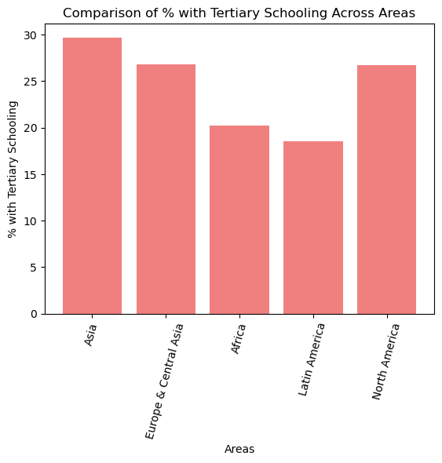

```python
#Extracting the 'Area' and '% with tertiary schooling' columns
areas = df4['Area']
percentages = df4['% with tertiary schooling']

#Defining the color
color = 'lightcoral'

#Creating the bar chart
fig, ax = plt.subplots()
ax.bar(areas, percentages, color=color, edgecolor='none')
ax.set_xlabel('Areas')
ax.set_ylabel('% with Tertiary Schooling')
ax.set_title('Comparison of % with Tertiary Schooling Across Areas')
plt.xticks(rotation=75)

#Displaying the chart
plt.show()
```

##### Interpretation

According to the graph, the area with the highest percentage of people with tertiary schooling is Asia, followed by Europe & Central Asia, and North America. The area with the lowest percentage is Latin America.

#### Distribution of the factors that contribute in evaluating happiness

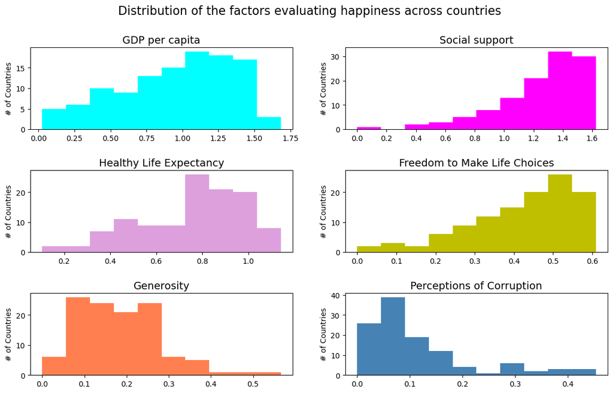

```python
#Distribution of the factors that contribute in evaluating the happiness

#Subplots
dist, ((x0, x1), (x2, x3), (x4,x5)) = plt.subplots(nrows=3, ncols=2, figsize=(14,8))
plt.suptitle('Distribution of the factors evaluating happiness across countries', fontsize=16)
plt.subplots_adjust(hspace=0.5)

#GDP
x0.hist(df4['GDP per capita'], histtype='bar', color='cyan')
x0.set_title('GDP per capita', fontsize=14)
x0.set_ylabel('# of Countries')

#Social Support
x1.hist(df4['Social support'], histtype='bar', color='magenta')
x1.set_title('Social support', fontsize=14)
x1.set_ylabel('# of Countries')

#Healthy life expectancy
x2.hist(df4['Healthy life expectancy'], histtype='bar', color='plum')
x2.set_title('Healthy Life Expectancy', fontsize=14)
x2.set_ylabel('# of Countries')

#Freedom to make life choices
x3.hist(df4['Freedom to make life choices'], histtype='bar', color='y')
x3.set_title('Freedom to Make Life Choices', fontsize=14)
x3.set_ylabel('# of Countries')

#Generosity
x4.hist(df4['Generosity'], histtype='bar', color='coral')
x4.set_title('Generosity', fontsize=14)
x4.set_ylabel('# of Countries')

#Perceptions of corruptions
x5.hist(df4['Perceptions of corruption'], histtype='bar', color='steelblue')
x5.set_title('Perceptions of Corruption', fontsize=14)
x5.set_ylabel('# of Countries')
```

##### Interpretation

The GDP, social support, healthy life expectancy and freedom to make choices histograms are skewed to the left, which means that most countries think that those variables contribute significantly in evaluating happiness in each country. On the other hand, the histograms for generosity and perception of corruptions are right skewed, which means that most countries think that those variables don't contribute significantly in evaluating happiness in each country.

### Basic summaries for the categorical variables

```python
#Getting the basic summaries for the categorical variables
df4[['Country','Region','Area','Happiness level', 'Income group', 'Income level']].describe()
```

|  | Country | Region | Area | Happiness level | Income group | Income level |
| --- | --- | --- | --- | --- | --- | --- |
| count | 115 | 115 | 115 | 115 | 115 | 115 |
| unique | 115 | 7 | 5 | 3 | 4 | 3 |
| top | Afghanistan | Europe & Central Asia | Africa | High | High income | Middle |
| freq | 1 | 36 | 39 | 46 | 41 | 62 |

```python
#Pandas Bar Plots for Areas
AreaCnts=DataFrame(df4.Area.value_counts())
AreaCnts
```

|  | Area |
| --- | --- |
| Africa | 39 |
| Europe & Central Asia | 36 |
| Asia | 19 |
| Latin America | 19 |
| North America | 2 |

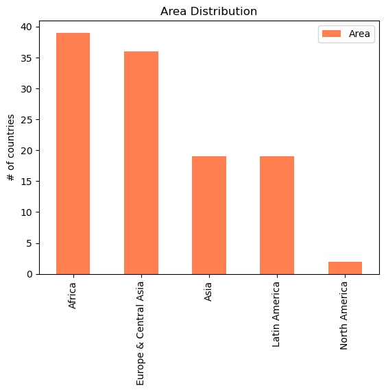

```python
#Plotting a bar chart with the different Areas
AreaCnts.plot.bar(color = 'coral')
plt.title('Area Distribution')
plt.ylabel('# of countries')
```

#### Interpretation

According to this graph, most of the countries of this research are in Africa, followed by Europe & Central Asia.

#### Distribution of the Happiness Levels

```python
#Pandas Bar Plots for Happiness level
HappinessCnts = pd.DataFrame(df4['Happiness level'].value_counts())
HappinessCnts
```

|  | Happiness level |
| --- | --- |
| High | 46 |
| Low | 38 |
| Medium | 31 |

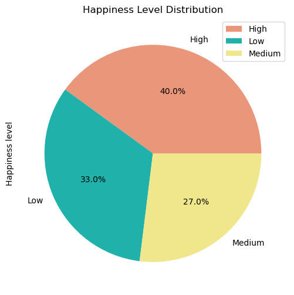

```python
#Plotting a pie chart with the different happiness levels
Colors = ['darksalmon','lightseagreen','khaki']
HappinessCnts.plot.pie(y='Happiness level', figsize=(6,6), autopct='%1.1f%%', colors=Colors)
plt.title('Happiness Level Distribution')
plt.show()
```

##### Interpretation

As seen in this graph, 40% of the countries of this research are considered to have a high level of happiness, while 33% have a low level, and 27% have a medium level of happiness.

#### Distribution of the Income Levels

```python
#Pandas Bar Plots for Income level
IncomeCnts = pd.DataFrame(df4['Income level'].value_counts())
IncomeCnts
```

|  | Income level |
| --- | --- |
| Middle | 62 |
| High | 41 |
| Low | 12 |

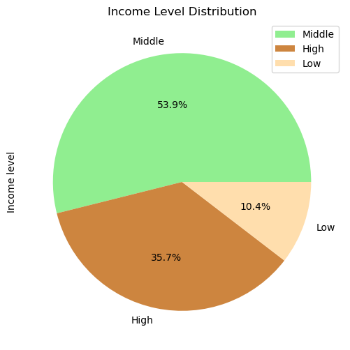

```python
#Plotting a chart with the different income levels
Colors1 = ['lightgreen','peru','navajowhite']
IncomeCnts.plot.pie(y='Income level', figsize=(6,6), autopct='%1.1f%%', colors=Colors1)
plt.title('Income Level Distribution')
plt.show()
```

##### Interpretation

As we can see in this graph, 53.9% of the countries of this research are considered middle-income, 35.7% are high-income, and 10.4% are low income countries.

### Summaries that compare multiple variables

#### Correlation between the factors that contribute in evaluating the happiness

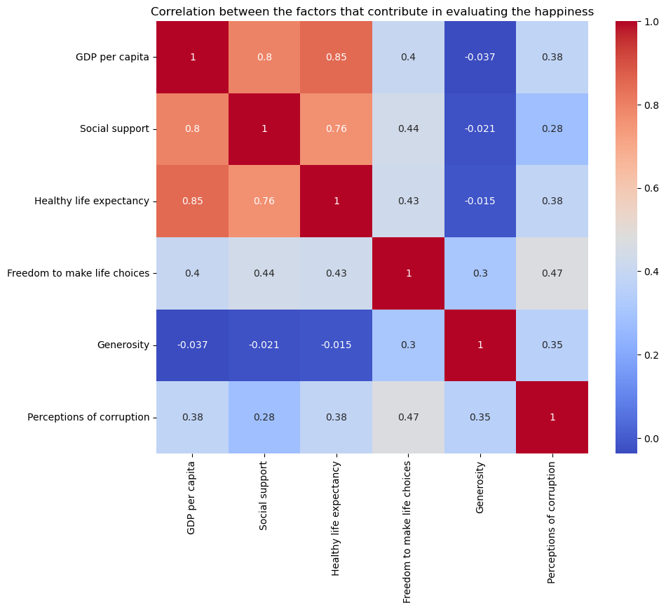

```python
#Creating the correlation matrix based on the selected factors
facthapp = ['GDP per capita', 'Social support', 'Healthy life expectancy', 'Freedom to make life choices', 'Generosity', 'Perceptions of corruption']
correlation_matrix = df4[facthapp].corr()
plt.figure(figsize=(10, 8))
sns.heatmap(correlation_matrix, annot=True, cmap='coolwarm', square=True)

#Adding a title and displaying the plot
plt.title('Correlation between the factors that contribute in evaluating the happiness')
plt.show()
```

#### Correlation between % with tertiary schooling and GPD per capita

```python
#Correlation between % with tertiary schooling and GPD per capita
corr1=df4['% with tertiary schooling'].corr(df4['GDP per capita'])
```

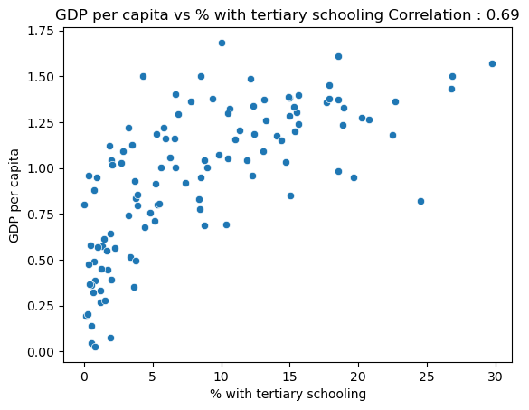

```python
#Plotting the correlation in a scatter plot
sns.scatterplot(data=df4, x='% with tertiary schooling', y='GDP per capita')
TGCorr = round(corr1,3)
plt.title(f'GDP per capita vs % with tertiary schooling Correlation : {TGCorr}')
plt.show()
```

##### Interpretation

I wanted to know whether the people that give more importance to the GDP are more likely to attend tertiary schooling. The relationship between these two variables is moderate and positive, which means that generally, people who give importance to the GDP per capita, tend to attend to tertiary schooling.

### Exploring each of the research questions

#### Question 1: What is the relationship between income and education level? What is the relationship between these variables across different areas?

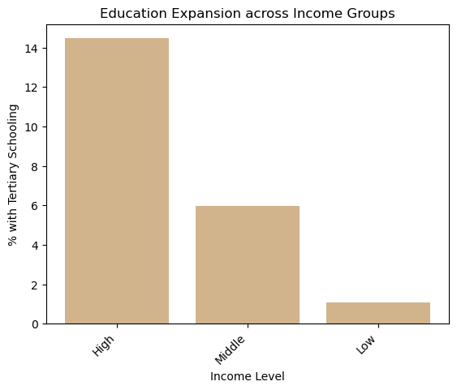

```python
#Grouping the data
grouped_data2 = df4.groupby('Income level')['% with tertiary schooling'].mean().reset_index()
grouped_data2 = grouped_data2.sort_values('% with tertiary schooling', ascending=False)

#Creating a bar chart using the 'Income level' and '% with tertiary schooling' columns
fig, ax = plt.subplots()
color1 = 'tan'
ax.bar(grouped_data2['Income level'], grouped_data2['% with tertiary schooling'], color=color1)

#Setting the x-axis locations
ax.set_xticks(range(len(grouped_data2['Income level'])))

#Setting the x-axis labels
ax.set_xticklabels(grouped_data2['Income level'], rotation=45, ha='right')

ax.set_xlabel('Income Level')
ax.set_ylabel('% with Tertiary Schooling')
ax.set_title('Education Expansion across Income Groups')

#Displaying the chart
plt.show()
```

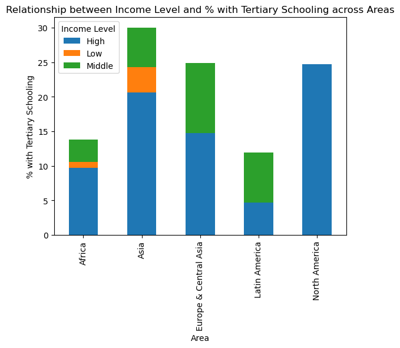

```python
#Grouping the data by 'Area' and 'Income level' and calculate the mean of '% with tertiary schooling'
grouped_data = df4.groupby(['Area', 'Income level'])['% with tertiary schooling'].mean().unstack()

#Creating a stacked bar chart
plt.figure(figsize=(10, 6))
colors = ['tab:blue', 'tab:orange', 'tab:green', 'tab:red']

grouped_data.plot(kind='bar', stacked=True, color=colors)

#Setting axis labels and title
plt.xlabel('Area')
plt.ylabel('% with Tertiary Schooling')
plt.title('Relationship between Income Level and % with Tertiary Schooling across Areas')

#Displaying legend
plt.legend(title='Income Level', loc='upper left')

#Displaying the chart
plt.show()
```

#### Question 2: How does income impact individual happiness?

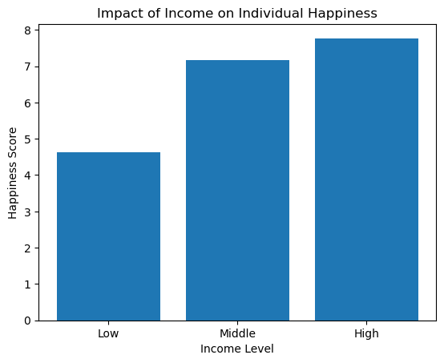

```python
#Creating a scatter plot to visualize the relationship between income and happiness for individual data points
plt.bar(df4['Income level'], df4['Happiness Score'])

plt.xlabel('Income Level')
plt.ylabel('Happiness Score')
plt.title('Impact of Income on Individual Happiness')

#Displaying the chart
plt.show()
```

##### Answer

The graph clearly illustrates a correlation between income levels and happiness scores across countries. High-income countries consistently exhibit higher happiness scores compared to low-income countries, with the highest reported score being around 8. On the other hand, low-income countries have the lowest happiness scores, with the highest reported score falling below 5.  
This correlation can be attributed to several factors. One key factor is the availability of resources and opportunities in high-income countries. Higher income levels often lead to better access to healthcare, education, infrastructure, and overall quality of life. These factors contribute to a greater sense of well-being and satisfaction among the population.  
Thus, this graph demonstrates a clear pattern where high-income countries tend to have higher happiness scores compared to low-income countries, while middle-income countries fall somewhere in between

#### Question 3: How does education impact individual happiness?

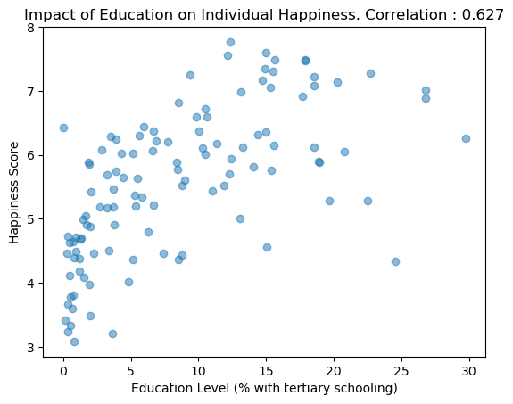

```python
#Correlation between Happiness and % with tertiary schooling
corr2=df4['% with tertiary schooling'].corr(df4['Happiness Score'])

#Extracting the education level and happiness score columns
education_levels = df4['% with tertiary schooling']
happiness_scores = df4['Happiness Score']

#Creating the scatter plot
plt.scatter(education_levels, happiness_scores, alpha=0.5)

#Adding labels and title
plt.xlabel('Education Level (% with tertiary schooling)')
plt.ylabel('Happiness Score')
THCorr = round(corr2,3)
plt.title(f'Impact of Education on Individual Happiness. Correlation : {THCorr}')

#Displaying the scatter plot
plt.show()
```

##### Answer

This research aims to investigate the relationship between educational attainment and happiness, specifically focusing on individuals who attend tertiary schooling. The correlation analysis reveals a moderate and positive relationship between happiness and education, with a correlation coefficient of 0.627. This indicates that, in general, as educational attainment increases, happiness levels also tend to rise.  
Several factors may contribute to this positive relationship. For example, higher education is frequently associated with better job prospects and higher income potential. The financial stability and security that come with higher-paying jobs can provide individuals with a greater sense of control and well-being, thus positively influencing happiness levels.  
Thus, the findings suggest that there is a notable association between higher levels of education and increased happiness. People who pursue tertiary education, such as college or university, appear to be more likely to experience higher levels of happiness compared to those with lower educational attainment.

#### Question 4: What is the relationship between education level, income, and happiness?

```python
#Correlation between Happiness Score and GPD per capita
corr3=df4['GDP per capita'].corr(df4['Happiness Score'])
print(corr3)
```

```
0.809336663989949
```

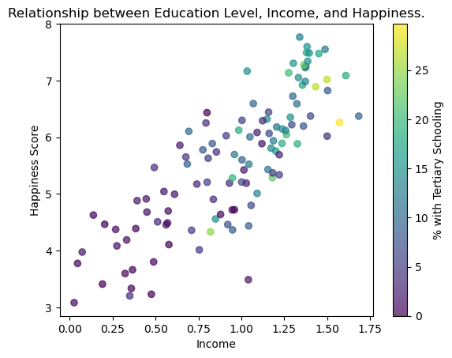

```python
#Extracting the relevant data columns
education_level = df4['% with tertiary schooling']
income = df4['GDP per capita']
happiness = df4['Happiness Score']

#Creating a scatter plot
fig, ax = plt.subplots()
scatter = ax.scatter(income, happiness, c=education_level, cmap='viridis', alpha=0.7)

#Adding colorbar and labels
cbar = plt.colorbar(scatter)
cbar.set_label('% with Tertiary Schooling')
ax.set_xlabel('Income')
ax.set_ylabel('Happiness Score')

#Adding a title
IHCorr = round(corr1,3)
plt.title(f'Relationship between Education Level, Income, and Happiness.')

#Displaying the scatter plot
plt.show()
```

##### Answer

This analysis suggests a connection between the importance of GDP per capita in evaluating happiness, the level of educational attainment, and the reported happiness scores. Countries where GDP per capita is more strongly associated with happiness often have higher levels of educational attainment and correspondingly higher happiness scores. This may indicate that a combination of economic prosperity and educational opportunities contributes to overall happiness levels in these countries. However, it is crucial to consider the multitude of factors that contribute to happiness and recognize that education and GDP per capita are just two aspects among many in shaping an individual's well-being.

## CONCLUSION

In summary, the findings from this research provide compelling evidence regarding the interplay between education, income, and happiness. They underscore the significance of education as a pathway to higher earnings, as countries with a higher percentage of people with tertiary schooling tend to have higher incomes. This correlation emphasizes the importance of investing in education systems and promoting access to quality education for individuals across all income levels.

Moreover, the data highlights the relationship between income and happiness, indicating that higher-income countries generally have higher happiness scores. While it is essential to acknowledge that happiness is a complex and multifaceted concept influenced by various factors, the strong positive association between income and happiness cannot be ignored. This suggests that a certain level of material well-being, facilitated by higher incomes, can contribute to overall life satisfaction and contentment.

Furthermore, the moderate and positive correlation between education and happiness suggests that educational attainment can also have a direct impact on an individual's well-being. Education not only enhances individuals' knowledge and skills but also opens doors to better job opportunities, financial stability, and personal growth. These factors, in turn, can positively influence one's sense of fulfillment and happiness.

Taken together, these findings underscore the interconnectedness of education, income, and happiness. They highlight the need for comprehensive policies that prioritize accessible and quality education, promote equitable income distribution, and strive for economic growth that benefits all segments of society. Such initiatives can contribute to creating a more prosperous and content population, fostering social and economic development, and enhancing overall quality of life. By recognizing and addressing these relationships, policymakers, educators, and individuals can work together to build a more equitable and fulfilling future for all.